# Attenuated, exaggerated, or flipped health disparities: Ramifications of measurement error on concentration indices

This repository contains `R` code to reproduce results from the manuscript by Hung, Green, and Lotspeich (2025+).

## Packages

Our implementation of the health disparities methods in the paper rely on the following `R` packages, which can be installed and loaded as follows.

```r
# Run once: install.packages(c("dplyr", "ggplot2", "latex2exp", "scales"))
library(dplyr) ## for data wrangling
library(ggplot2) ## for plots
library(latex2exp) ## for LaTeX in plots
library(scales) ## for percent labels in plots

# Run once: devtools::install_github("sarahlotspeich/ggconc")
library(ggconc) ## for concentration curves

# Run once: devtools::install_github("sarahlotspeich/mochi")
library(mochi) ## for moment-based correction
```

## Electronic Health Records Data: Diabetes and Proximity to Healthy Foods

We begin with the electronic health records (EHR) data from our previous work, which already has diabetes diagnosis (yes/no) and proximity to healthy foods (both error-free and error-prone). With permission from the Institutional Review Board at Wake Forest University School of Medicine, this de-identified version of the study dataset was made available with our prior work as Supplementary Material. These data can be loaded as follows.

```r
# Read in the data from CSV
ehr_food = read.csv("https://raw.githubusercontent.com/sarahlotspeich/ME_Disparities_HSORM/refs/heads/main/me_disparities_analysis_2020.csv") |>
  select(ID, MAP_PROXIMITY, STRAIGHT_PROXIMITY)

## Inspect data summary
ehr_food |>
  summary()
```

```
##        ID        MAP_PROXIMITY       STRAIGHT_PROXIMITY
##  Min.   :  1.0   Min.   :2.880e-05   Min.   :2.880e-05
##  1st Qu.:231.8   1st Qu.:9.503e-01   1st Qu.:6.074e-01
##  Median :462.5   Median :1.701e+00   Median :1.140e+00
##  Mean   :462.5   Mean   :2.512e+00   Mean   :1.738e+00
##  3rd Qu.:693.2   3rd Qu.:3.572e+00   3rd Qu.:2.291e+00
##  Max.   :924.0   Max.   :1.547e+01   Max.   :1.019e+01
```

We retain the following columns from the full electronic health records (EHR) dataset.

- `ID`: a deidentified patient identifier
- `MAP_PROXIMITY`: error-free, map-based proximity to healthy foods (in miles)
- `STRAIGHT_PROXIMITY`: error-prone, straight-line proximity to healthy foods (in miles)

Each row represents data for one patient. We also add columns with the fractional ranks for all patients based on `MAP_PROXIMITY` and `STRAIGHT_PROXIMITY`.

```r
# Add columns for fractional ranks based on error-prone and error-free X
ehr_food = ehr_food |>
  mutate(STRAIGHT_RANK = (rank(-STRAIGHT_PROXIMITY) - 1) / n() + 1 / (2 * n()),
         MAP_RANK = (rank(-MAP_PROXIMITY) - 1) / n() + 1 / (2 * n()))
```

## Monte Carlo Simulation: Generating Hemoglobin A1c

For the current work, we wanted to simulate hemoglobin A1c (HbA1c, a biomarker for blood glucose that is key for monitoring type-2 diabetes) for these patients. The goal was to demonstrate how these patients’ error-prone versus error-free proximity to healthy foods (from the real EHR data) may tell a different story about potential disparities in HbA1c. In the code chunk below, we demonstrate how HbA1c was generated for a single Monte Carlo simulation, where the targeted magnitude of the disparity was $C \approx 0.5$.

```r
# Set parameters to generate Y|X
## You will want to play around with these...
beta0 = 3    ## average HbA1c for patients with optimal proximity (0 miles)
beta1 = 0.3    ## coefficient on proximity (in miles)

# Add column with generated Y|R
set.seed(918) ## for reproducibility
ehr_food = ehr_food |>
  mutate(HBA1C = rlnorm(n = n(),
                        mean = beta0 + beta1 * MAP_PROXIMITY,
                        sd = 1))

## Inspect data summary
ehr_food |>
  summary()
```

```
##        ID        MAP_PROXIMITY       STRAIGHT_PROXIMITY  STRAIGHT_RANK
##  Min.   :  1.0   Min.   :2.880e-05   Min.   :2.880e-05   Min.   :0.0005411
##  1st Qu.:231.8   1st Qu.:9.503e-01   1st Qu.:6.074e-01   1st Qu.:0.2502706
##  Median :462.5   Median :1.701e+00   Median :1.140e+00   Median :0.5000000
##  Mean   :462.5   Mean   :2.512e+00   Mean   :1.738e+00   Mean   :0.5000000
##  3rd Qu.:693.2   3rd Qu.:3.572e+00   3rd Qu.:2.291e+00   3rd Qu.:0.7497294
##  Max.   :924.0   Max.   :1.547e+01   Max.   :1.019e+01   Max.   :0.9994589
##     MAP_RANK             HBA1C
##  Min.   :0.0005411   Min.   :   1.712
##  1st Qu.:0.2502706   1st Qu.:  20.347
##  Median :0.5000000   Median :  40.415
##  Mean   :0.5000000   Mean   : 112.392
##  3rd Qu.:0.7497294   3rd Qu.:  90.718
##  Max.   :0.9994589   Max.   :7467.420
```

## Exploratory Data Analysis

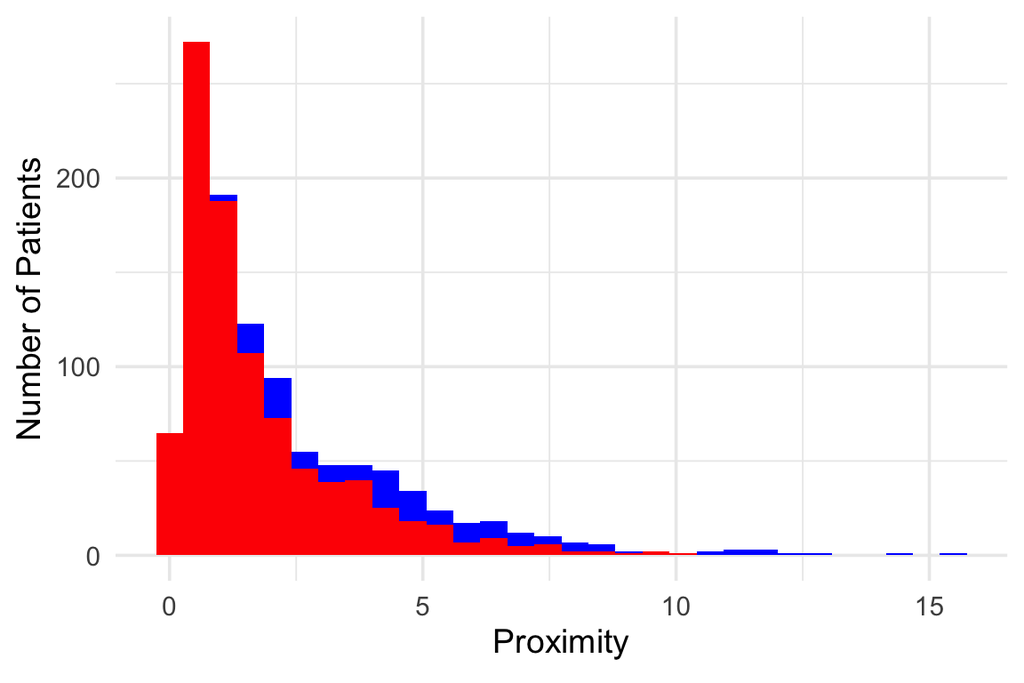

```r
ehr_food |>
  ggplot() +
  geom_histogram(aes(x = MAP_PROXIMITY), fill = "blue") +
  geom_histogram(aes(x = STRAIGHT_PROXIMITY), fill = "red") +
  theme_minimal(base_size = 14) +
  labs(x = TeX("Proximity"),
       y = TeX("Number of Patients"))
```

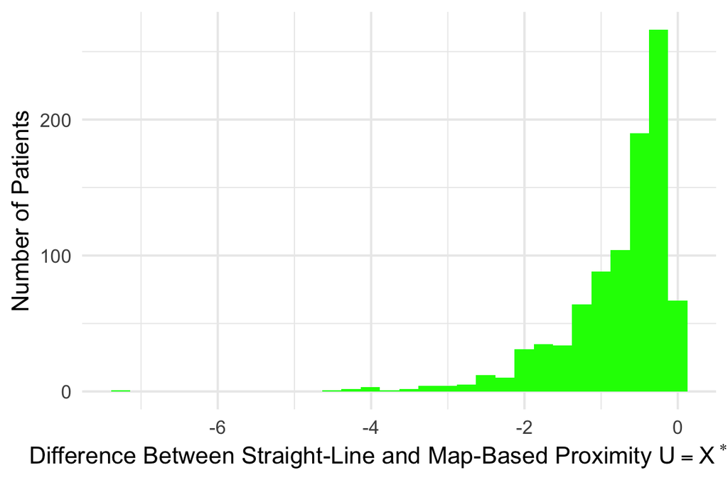

```r
ehr_food |>
  ggplot() +
  geom_histogram(aes(x = STRAIGHT_PROXIMITY - MAP_PROXIMITY),
                 fill = "green") +
  theme_minimal(base_size = 14) +
  labs(x = TeX("Difference Between Straight-Line and Map-Based Proximity $U = X^*-X$"),
       y = TeX("Number of Patients"))
```

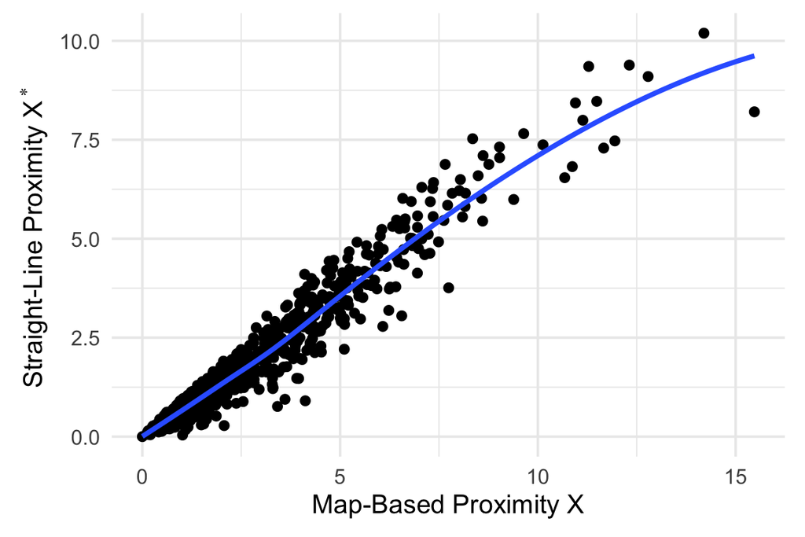

```r
ehr_food |>
  ggplot(aes(x = MAP_PROXIMITY, y = STRAIGHT_PROXIMITY)) +
  geom_point() +
  geom_smooth(se = FALSE) +
  coord_equal() +
  theme_minimal(base_size = 14) +
  labs(x = TeX("Map-Based Proximity $X$"),
       y = TeX("Straight-Line Proximity $X^*$"))
```

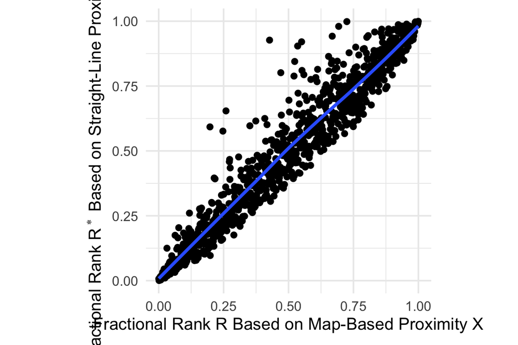

```r
ehr_food |>
  ggplot(aes(x = MAP_RANK, y = STRAIGHT_RANK)) +
  geom_point() +
  geom_smooth(se = FALSE) +
  coord_equal() +
  theme_minimal(base_size = 14) +
  labs(x = TeX("Fractional Rank $R$ Based on Map-Based Proximity $X$"),
       y = TeX("Fractional Rank $R^*$ Based on Straight-Line Proximity $X^*$"))
```

## Analysis

### Concentration Curves

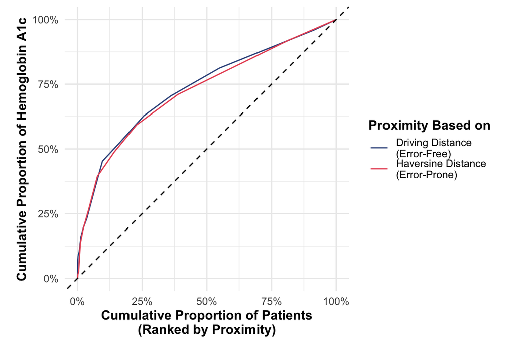

```r
ehr_food |>
  ggplot() +
  geom_concentration(aes(x = MAP_PROXIMITY, y = HBA1C, color = "Driving Distance\n(Error-Free)"),
                      rank_ascend = FALSE, round_rank = 0) +
  geom_concentration(aes(x = STRAIGHT_PROXIMITY, y = HBA1C, color = "Haversine Distance\n(Error-Prone)"),
                      rank_ascend = FALSE, round_rank = 0) +
  geom_abline(slope = 1, intercept = 0, linetype = 2) +
  scale_color_manual(values = c("Driving Distance\n(Error-Free)" = "#39558CFF",
                                "Haversine Distance\n(Error-Prone)" = "#E85362FF"),
                     name = "Proximity Based on") +
  coord_equal() +
  theme_minimal() +
  labs(x = "Cumulative Proportion of Patients\n(Ranked by Proximity)",
       y = "Cumulative Proportion of Hemoglobin A1c") +
  theme(axis.title = element_text(face = "bold"),
        legend.title = element_text(face = "bold")) +
  scale_x_continuous(labels = label_percent()) +
  scale_y_continuous(labels = label_percent())
```

### Concentration Index

```r
## Concentration index based on straight-line proximity (unbinned)
ci_straight = ci(ineqvar = ehr_food$NEG_STRAIGHT_PROXIMITY, ### Food environment exposure
                 outcome = ehr_food$HBA1C, ### Health outcome
                 type = "CIw", ### Wagstaff's correction for binary health outcome
                 robust_se = TRUE) ### Use sandwich standard errors for confidence interval
summary(ci_straight)

## Concentration index based on map-based proximity (unbinned)
ci_map = ci(ineqvar = ehr_food$NEG_MAP_PROXIMITY, ### Food environment exposure
                 outcome = ehr_food$HBA1C, ### Health outcome
                 type = "CIw", ### Wagstaff's correction for binary health outcome
                 robust_se = TRUE) ### Use sandwich standard errors for confidence interval
summary(ci_map)
```

[output not shown]